# Intro to git and version control

Professor Tyler McCormick  
April 5, 2019

Drawing heavily on material from [happygitwithr](http://happygitwithr.com/) by @JennyBryan and collaborators and François Michonneau's [R for biologists](http://r-bio.github.io/).

### Objectives

- Install git and explain the Git workflow
- Be able to define the key Git actions: clone, push, commit, etc
- Write a document in Markdown
- Successfully perform your git+RStudio workflow with this document

### What is version control?

[figure not shown]

### What is version control?

Version control is a category of software that keep track of changes to your files for you. It allows you to:

- keep the entire history of a file and inspect a file throughout its life time
- tag particular version so you can go back to them easily
- facilitates collaborations and makes contributions transparent
- experiment with code and feature without breaking the main project

### Git and GitHub

## What is Git?

Git is a particular implementation of version control. It's really powerful and has many features but we will only scratch the surface.

## What is GitHub?

When you start a Git project on your computer, you are going to store the entire history of the project locally. The storage of your project and its history is called a **repository**. It is fine. However, the great advantage of using version control such as Git is to be able to collaborate with other people (and also to store your repository somewhere else).

### Git and GitHub

GitHub is a commercial website that lets you store your repository publicly for free (you need to pay if you want to keep them private, you can also get an educative account with an `.edu` email address that will give you some free private accounts). There are other website that offer similar services including BitBucket. Storing your repositories on these website has many advantages. It offers a friendly interface to many common operations so that you don't have to remember how to do them at the command line. They also provide other useful features including an “Issue tracker” and wikis.

### The Git workflow

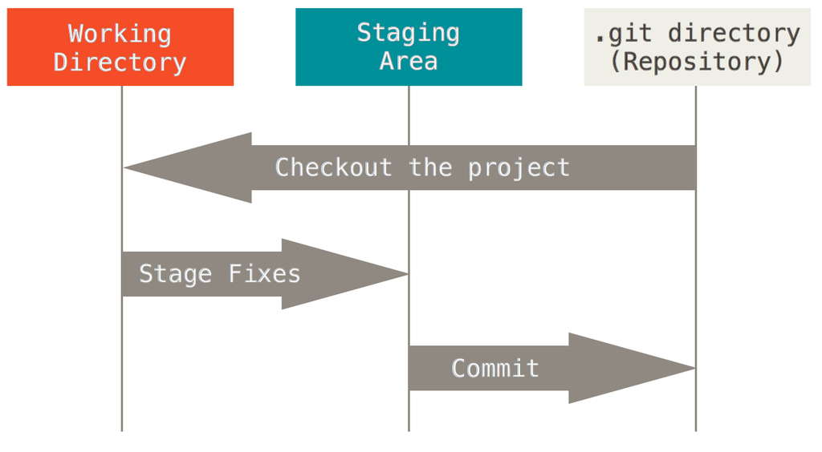

### The Git workflow

The typical workflow goes like this:

- you **clone** a repository to get access to the files at one point in time
- you create/edit/modify a file inside your repository
- you **stage** the changes to the staging area
- you **commit** these changes which creates a permanent snapshot of the file in the Git directory along with a message that indicates what you did to the file.
- you **push** the changes back to the the GitHub server.

### Commits

When you start a new project, the files in your working directory are **untracked**, you will first need to **add** them to your repository before Git can keep track of them and their history.

At this stage, everything is still on your hard drive. To upload your modifications (i.e., your commits) to GitHub you need to **push** to it.

If you are working with other people you are also committing your shared repository on GitHub, you will need to **pull** to bring their modifications into your local copy of the repository.

Commits are cheap. Commit often and provide useful messages so you can keep track of what you are doing. Don't do this:

### Commits

[figure not shown]

(From xkcd.com)

### Branching

Branching is a great feature of version control. It allows you to duplicate your existing repository, develop or experiment with a new feature independently, and if you like what you are doing you can **merge** these modifications back into your project.

Branching is particularly important with Git as it is the mechanism that is used when you are collaborating to external projects (projects you are not directly involved with).

### Pull requests

With a **pull request** you are asking someone who maintains a repository to pull your changes into their repository.

To issue a pull request:

1. First, you need a copy of the repository that contains the code you want to improve. To do so, you will **fork** it from its original location. You will also need to tell Git that this a copy of another project (a.k.a., **upstream**)
2. You need to import the code onto your computer. To do so, you will **clone** your fork to your computer.

### Pull requests

1. Now that the code is on your computer, you can edit and modify it. Once you are done you can **push** it to your repository.
2. Once the code is in your repository, you can issue a pull request so the original owner of the code (**upstream**) can review, comment, accept (or reject) your proposed modifications.
3. At some point, you will need to **pull** changes that occur upstream into your own repository if you want to keep contributing to the project.

### How does git compare with other systems?

[figure not shown]

### What is the payoff?

**Exposure**: If someone needs to see your work or if you want them to try out your code, they can easily get it from GitHub. If they use Git, they can clone or fork your repository. If they don't use Git, they can still browse your project on GitHub like a normal website and even grab everything by downloading a zip archive.

**Be a keener!** If you care deeply about someone else's project, such as an R package you use heavily, you can track its development on GitHub. You can watch the repository to get notified of major activity. You can fork it to keep your own copy. You can modify your fork to add features or fix bugs and send them back to the owner as a proposed change.

### What is the payoff?

**Collaboration**: If you need to collaborate on data analysis or code development, then everyone should use Git. Use GitHub as your clearinghouse: individuals work independently, then send work back to GitHub for reconciliation and transmission to the rest of the team. The advantage of Git/GitHub is highlighted by comparing these two ways of collaborating on a document:

- **Edit, save, attach.** In this workflow, everyone has one (or more!) copies of the document and they circulate via email attachment. Which one is “master”? Is it even possible to say? How do different versions relate to each other? How should versions be reconciled? If you want to see the current best version, how do you get it? All of this usually gets sorted out by social contract and a fairly manual process.

### What is the payoff?

- **Google Doc.** In this workflow, there is only one copy of the document and it lives in the cloud. Anyone can access the most recent version on demand. Anyone can edit or comment or propose a change and this is immediately available to everyone else. Anyone can see who's been editing the document and, if disaster strikes, can revert to a previous version. A great deal of ambiguity and annoying reconciliation work has been designed away.

Managing a project via Git/GitHub is much more like the Google Doc scenario and enjoys many of the same advantages. It is definitely more complicated than collaborating on a Google Doc, but this puts you in the right mindset.

### Our workflow

1. Create a directory on GitHub
2. Load into RStudio
3. Write codes!
4. Use RStudio to commit your changes and push to GitHub

### Our workflow

[figure not shown]

### Installation overview:

You'll need to:

1. **Install R and RStudio and have a github account**
2. Install git
3. Configure git to talk to your GitHub account
4. Let RStudio know you're working with git

### Installation overview:

You'll need to:

1. Install R and RStudio and have a GitHub account
2. **Install git**
3. Configure git to talk to your GitHub account
4. Let RStudio know you're working with git

### Install git: Windows

**Option 1** (*recommended*): Install [Git for Windows](https://git-for-windows.github.io/), previously known as `msysgit` or “Git Bash”, to get Git in addition to some other useful tools, such as the Bash shell. Yes, all those names are totally confusing. You may accept all the default settings during installation.

### Install git: Windows

**Option 2** (*NOT recommended*): The GitHub hosting site offers [GitHub Desktop for Windows](https://desktop.github.com/) that provides Git itself, a client, and smooth integration with GitHub.

- [Their Windows set-up instructions](https://help.github.com/articles/set-up-git#platform-windows) recommend this method of Git installation.
- Why don't we like it? We've seen GitHub Desktop for Windows lead to Git installation in sub-optimal locations, such as `~/AppData/Local`, and in other places we could never find. If you were **only** going to interact with GitHub via this app, maybe that's OK, but that does not apply to you. Therefore, we recommend option 1 instead.

### Install git: Mac OS

**Option 1** (*highly recommended*): Install the Xcode command line tools (not all of Xcode), which includes Git. If your OS is older than 10.11 El Capitan, it is possible that you **must** install the Xcode command line tools in order for RStudio to find and use Git.

Go to the shell and enter one of these commands to elicit an offer to install developer command line tools:

```bash
git --version
git config
```

Accept the offer! Click on “Install”.

Another way to request this is via `xcode-select --install`. We just happen to find this Git-based trigger apropos.

### Install git: Mac OS

**Option 2** (*recommended*): Install Git from here: http://git-scm.com/downloads.

- This arguably sets you up the best for the future. It will certainly get you the latest version of Git of all approaches described here.
- The GitHub home for this project is here: https://github.com/timcharper/git_osx_installer.
  - At that link, there is a list of maintained builds for various combinations of Git and Mac OS version. If you're running 10.7 Lion and struggling, we've had success in September 2015 with binaries found here: https://www.wandisco.com/git/download.

### Install git: Mac OS

**Option 3** (*recommended*): If you anticipate getting heavily into scientific computing, you're going to be installing and updating lots of software. You should check out [homebrew](http://brew.sh), “the missing package manager for OS X”. Among many other things, it can install Git for you. Once you have Homebrew installed, do this in the shell:

```
brew install git
```